# **Assignment 6: Analysis of longitudinal data**

This week the aim was to study two different datasets with repeated measurements on each subject. Repeated measurements pose problems for the analysis as they are usually correlated rather than independent.

**PART I: Rats**

First dataset to analyze consists of observations 16 rats and their body weight evolution. The rats were divided into three groups that received different diets. The body weight was measured weekly over 9 weeks. The weekly observations are first gathered into long form. A plot showing the weight development of each individual rat is shown below.

```r
library(tidyr); library(dplyr)
```

```r
library(ggplot2); library(GGally)
# Read the RATS data
RATS <- read.table("https://raw.githubusercontent.com/KimmoVehkalahti/MABS/master/Examples/data/rats.txt",  header = TRUE, sep = '\t')

glimpse(RATS)
```

```
## Rows: 16
## Columns: 13
## $ ID    <int> 1, 2, 3, 4, 5, 6, 7, 8, 9, 10, 11, 12, 13, 14, 15, 16
## $ Group <int> 1, 1, 1, 1, 1, 1, 1, 1, 2, 2, 2, 2, 3, 3, 3, 3
## $ WD1   <int> 240, 225, 245, 260, 255, 260, 275, 245, 410, 405, 445, 555, 470,…
## $ WD8   <int> 250, 230, 250, 255, 260, 265, 275, 255, 415, 420, 445, 560, 465,…
## $ WD15  <int> 255, 230, 250, 255, 255, 270, 260, 260, 425, 430, 450, 565, 475,…
## $ WD22  <int> 260, 232, 255, 265, 270, 275, 270, 268, 428, 440, 452, 580, 485,…
## $ WD29  <int> 262, 240, 262, 265, 270, 275, 273, 270, 438, 448, 455, 590, 487,…
## $ WD36  <int> 258, 240, 265, 268, 273, 277, 274, 265, 443, 460, 455, 597, 493,…
## $ WD43  <int> 266, 243, 267, 270, 274, 278, 276, 265, 442, 458, 451, 595, 493,…
## $ WD44  <int> 266, 244, 267, 272, 273, 278, 271, 267, 446, 464, 450, 595, 504,…
## $ WD50  <int> 265, 238, 264, 274, 276, 284, 282, 273, 456, 475, 462, 612, 507,…
## $ WD57  <int> 272, 247, 268, 273, 278, 279, 281, 274, 468, 484, 466, 618, 518,…
## $ WD64  <int> 278, 245, 269, 275, 280, 281, 284, 278, 478, 496, 472, 628, 525,…
```

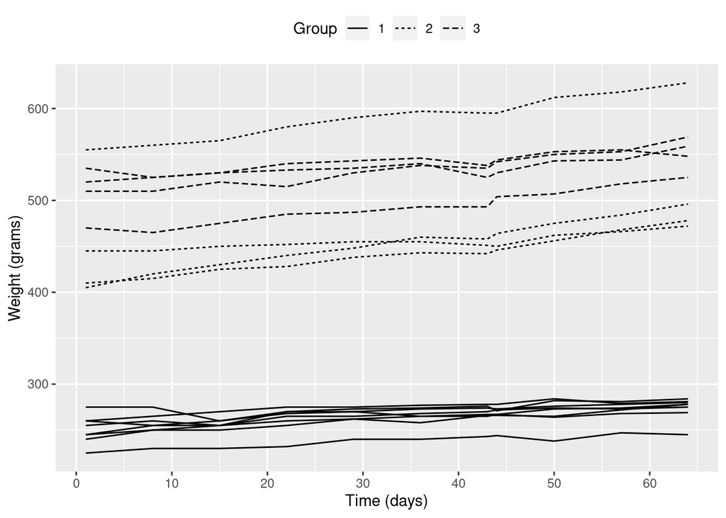

```r
# Factor variables ID and Group
RATS$ID <- factor(RATS$ID)
RATS$Group <- factor(RATS$Group)

# Convert data to long form and extract Time variable as integer
RATSL <- RATS %>%
  gather(key = WD, value = Weight, -ID, -Group) %>%
  mutate(Time = as.integer(substr(WD,3,4)))

ggplot(RATSL, aes(x = Time, y = Weight, group = ID)) +
  geom_line(aes(linetype = Group)) +
  scale_x_continuous(name = "Time (days)", breaks = seq(0, 60, 10)) +
  scale_y_continuous(name = "Weight (grams)") + theme(legend.position = "top")
```

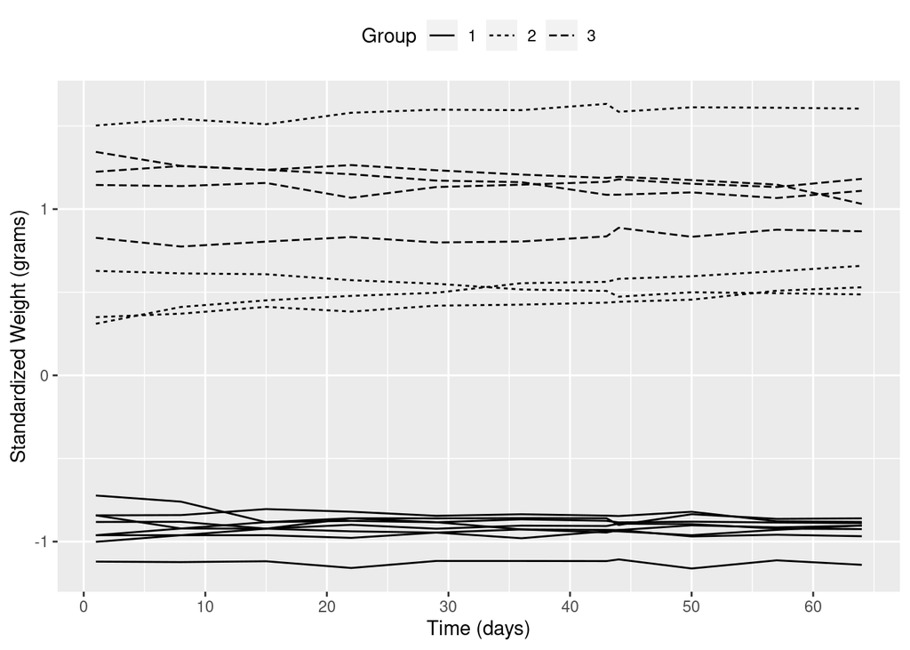

```r
# Standardise the variable Weight
RATSL <- RATSL %>%
  group_by(Time) %>%
  mutate(stdweight = (Weight - mean(Weight))/sd(Weight) ) %>%
  ungroup()

# Plot again with the standardized Weight
ggplot(RATSL, aes(x = Time, y = stdweight, group = ID)) +
  geom_line(aes(linetype = Group)) +
  scale_x_continuous(name = "Time (days)", breaks = seq(0, 60, 10)) +
  scale_y_continuous(name = "Standardized Weight (grams)") + theme(legend.position = "top")
```

The lines representing the weight development of individual rats in the figure above suggest that there may be some differences between the groups. To study this better, a mean of each group is taken and plotted below. (Here I got a bit lost as I was not sure if n was supposed to represent the amount of time steps / measurements like in the DataCamp exercise or number of individuals in a group like in the correction of the exercise. I chose the first option simply because the group sizes were not even: Group 1 has 8 individuals while groups 2 and 3 have four in each.)

```r
# Number of weeks, baseline (week 0) included
n <- 11

# Summary data with mean and standard error of Weight by Group and week
RATSS <- RATSL %>%
  group_by(Group, Time) %>%
  summarise( mean = mean(Weight), se = sd(Weight)/sqrt(n) ) %>%
  ungroup()
```

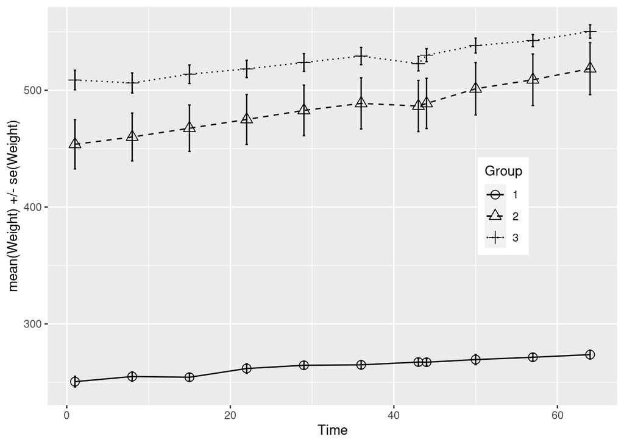

```r
# Plot the mean profiles
ggplot(RATSS, aes(x = Time, y = mean, linetype = Group, shape = Group)) +
  geom_line() + scale_linetype_manual(values = c(1,2,3)) +
  geom_point(size=3) +
  scale_shape_manual(values = c(1,2,3)) +
  geom_errorbar(aes(ymin = mean - se, ymax = mean + se, linetype="1"), width=0.3) +
  theme(legend.position = c(0.8,0.5)) +
  scale_y_continuous(name = "mean(Weight) +/- se(Weight)")
```

From the means above it can be seen that Group has higher standard error than the other two groups. It might be worthwhile to check what is going on there. The distributions are analyzed with boxplots in the figure below.

```r
# Create a summary data by Group and ID with mean as the summary variable (ignoring baseline week 0).
RATSL8S <- RATSL %>%
  filter(Time > 0) %>%
  group_by(Group, ID) %>%
  summarise( mean=mean(Weight) ) %>%
  ungroup()
```

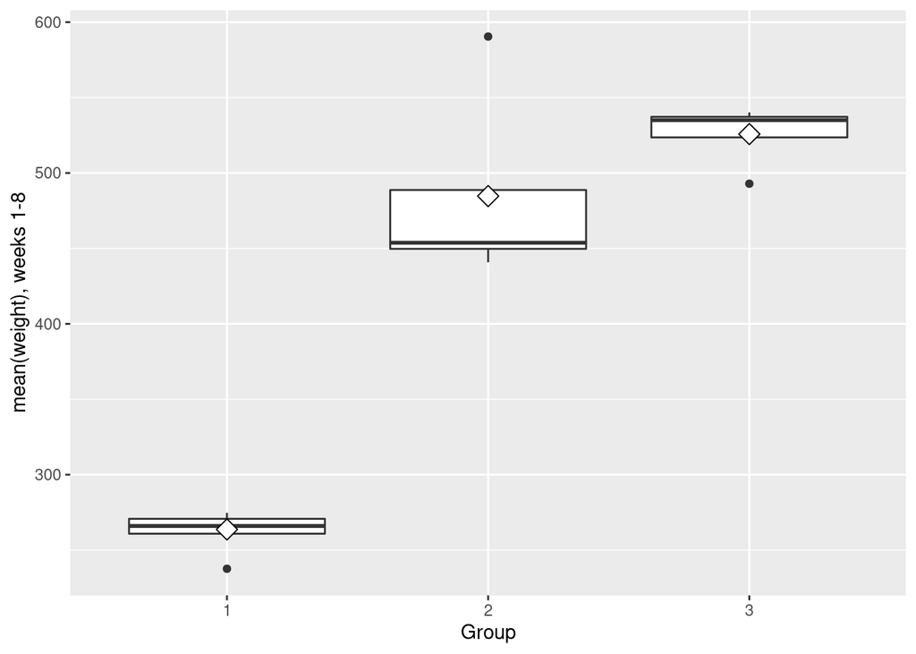

```r
# Draw a boxplot of the mean versus treatment
ggplot(RATSL8S, aes(x = Group, y = mean)) +
  geom_boxplot() +
  stat_summary(fun = "mean", geom = "point", shape=23, size=4, fill = "white") +
  scale_y_continuous(name = "mean(weight), weeks 1-8")
```

The boxplots reveal that all the groups have outliers, but in Group the outlier is causing quite strong skewedness. Therefore it should be removed and filtered out.

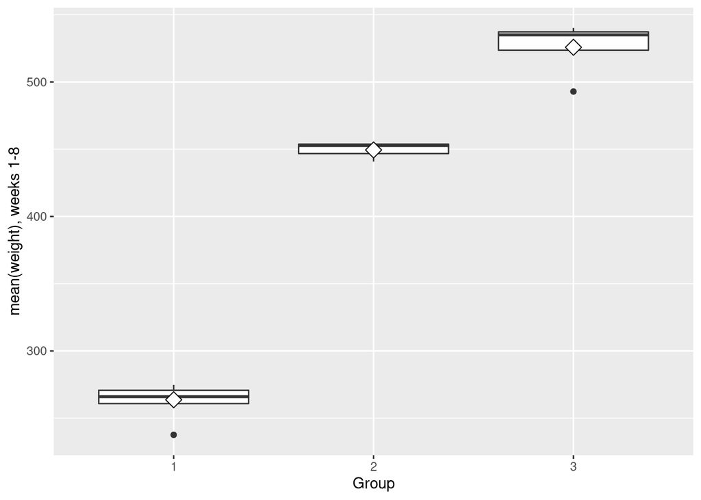

```r
# Create a new data by filtering the outlier and adjust the ggplot code the draw the plot again with the new data
RATSL8S1 <- RATSL8S %>%
  filter(mean < 550)

ggplot(RATSL8S1, aes(x = Group, y = mean)) +
  geom_boxplot() +
  stat_summary(fun = "mean", geom = "point", shape=23, size=4, fill = "white") +
  scale_y_continuous(name = "mean(weight), weeks 1-8")
```

New boxplots without the outlier (above) seem better. Group 3 is still a bit skewed, but I can live with this and continue to perform t-test. As t-tests are used to define if the significance between two samples are significantly different and here three groups are studied, I compared groups 1 and 2, groups 1 and 3 and groups 2 and 3 together. As seen from the results below, the p-values are low for all comparisons and therefore it seems that the diets really influence the weight development.

```r
# Perform t-test on groups 1 & 2
t.test(mean[1:11] ~ Group[1:11], data = RATSL8S1, var.equal = TRUE)
```

```
##
##  Two Sample t-test
##
## data:  mean[1:11] by Group[1:11]
## t = -24.838, df = 9, p-value = 1.334e-09
## alternative hypothesis: true difference in means between group 1 and group 2 is not equal to 0
## 95 percent confidence interval:
##  -202.6549 -168.8224
## sample estimates:
## mean in group 1 mean in group 2
##        263.7159        449.4545
```

```r
# Perform t-test on groups 1 & 3
t.test(mean[c(1:8,12:15)] ~ Group[c(1:8,12:15)], data = RATSL8S1, var.equal = TRUE)
```

```
##
##  Two Sample t-test
##
## data:  mean[c(1:8, 12:15)] by Group[c(1:8, 12:15)]
## t = -27.361, df = 10, p-value = 9.848e-11
## alternative hypothesis: true difference in means between group 1 and group 3 is not equal to 0
## 95 percent confidence interval:
##  -283.4218 -240.7373
## sample estimates:
## mean in group 1 mean in group 3
##        263.7159        525.7955
```

```r
# Perform t-test on groups 2 & 3
t.test(mean[9:15] ~ Group[9:15], data = RATSL8S1, var.equal = TRUE)
```

```
##
##  Two Sample t-test
##
## data:  mean[9:15] by Group[9:15]
## t = -5.6287, df = 5, p-value = 0.002452
## alternative hypothesis: true difference in means between group 2 and group 3 is not equal to 0
## 95 percent confidence interval:
##  -111.20490  -41.47691
## sample estimates:
## mean in group 2 mean in group 3
##        449.4545        525.7955
```

I also use the baseline as a separate variable to see how it relates to the different diets between different groups. From the results shown below, it is seen that the baseline correlates significantly with the individuals response to the diet. However, differences between the groups are not significant (Pr(>F) > 0.05).

```r
# Add the baseline from the original data as a new variable to the summary data
RATSL8S2 <- RATSL8S %>%
  mutate(baseline = RATS$WD1)

# Fit the linear model with the mean as the response
fit <- lm(mean ~ baseline + Group, data = RATSL8S2)

# Compute the analysis of variance table for the fitted model with anova()
anova(fit)
```

```
## Analysis of Variance Table
##
## Response: mean
##           Df Sum Sq Mean Sq   F value    Pr(>F)
## baseline   1 252125  252125 2237.0655 5.217e-15 ***
## Group      2    726     363    3.2219   0.07586 .
## Residuals 12   1352     113
## ---
## Signif. codes:  0 '***' 0.001 '**' 0.01 '*' 0.05 '.' 0.1 ' ' 1
```

**PART II: Psychiatric patients**